# Untitled

Zachary M. Smith

January 2, 2019

01-30-2019

# Overview

This document was created to provide an example of how to develop an MMI or IBI using the **mmir** R-package.

# Preparation

Install the **tidyverse** packages developed by R Studio. This is a collection of packages that make it easier to import, manipulate, and plot data. The package, **devtools**, must be installed to use the `devtools::install_github()` function. **plyr** will need to be installed to use `plyr::join_all()`. You will also need to install the **DT** package if you want to create the interactive tables found below.

```r
install.packages("tidyverse", "devtools", "plyr", "DT")
```

Only the **tidyverse** packages will be loaded into the environment to avoid any potential conflicts. The majority of functions in this document will be called using `::`. A package is specified on the left side of `::` and a function within that package is specified to the right of `::` (`package::function()`). For example, `dplyr::filter()` specifies that we are using the `filter()` function from the **dplyr** package and not the `filter()` function from the **stats** package. It is generally not necessary to use `::` in your own scripts but in this document I hope it clarifies where the function comes from and aids in your understanding of the script.

```r
suppressPackageStartupMessages(
  library(tidyverse)
)
```

Install the Multi-Metric Index (MMI) package, **mmir**, that I am developing from Git Hub. Make sure you install the development version of **mmir** (`ref = "dev"`).

```r
devtools::install_github("zsmith27/mmir", ref = "dev", force = TRUE, quiet = TRUE)
devtools::install_github("zsmith27/toolbox", force = TRUE, quiet = TRUE)
```

Once **mmir** is installed, load the packages with `library()`.

```r
library(mmir)
```

Find project root directory. This will make it easier to specify file paths later in this document.

```r
root.dir <- rprojroot::find_root("lgss.Rproj")
```

```r
attributes.df <- data.table::fread(file.path(root.dir,
                                             "data",
                                             "macro_taxa_hier_attributes_2018-12-04.csv"))
# attributes.df[attributes.df == ""]  <- NA

# attributes.df2 <- fill_taxa(attributes.df,
#                             fill.id.col = final_id,
#                             kingdom:subspecies)
```

```r
# taxa.df <- readxl::read_excel(file.path(root.dir,
#                                         "data",
#                                         "2015_LGSS_bugs_only.xlsx"),
#                               sheet = "Bugs") %>%

taxa.df <- read_csv(file.path(root.dir,
                              "data",
                              "Bugs.csv")) %>%
  select(-X461, -'Grand Total') %>%
  gather(final_id, count, -BAS_LOC_RM) %>%
  filter(!is.na(count)) %>%
  mutate(final_id = str_replace_all(final_id," ", "_"),
         final_id = str_to_lower(final_id)) %>%
  rename_all(tolower)
missing.df <- taxa.df %>%
  select(final_id) %>%
  distinct() %>%
  anti_join(attributes.df, by = c("final_id" = "macro_genspecies"))
```

```r
taxa.df <- taxa.df %>%
  rename(macro_genspecies = final_id) %>%
  left_join(attributes.df, by = "macro_genspecies") #%>%
  # fill_taxa(taxa.df, final_id, kingdom:subspecies)
```

```r
taxa.df <- read.csv(file.path(root.dir, "data", "LGSS_merge.csv"),
                    stringsAsFactors = FALSE) %>%
  # toolbox::prep_df() %>%
  # rename("FINAL_ID" = "GENSPECIES") %>%
  mutate(FINAL_ID = str_replace_all(GENSPECIES," ", "_"),
         FINAL_ID = str_to_upper(FINAL_ID)) %>%
  left_join(attributes.df, by = "FINAL_ID") %>%
  rename_all(tolower) %>%
  mutate_if(is.character,tolower)
```

```r
taxa.df <- taxa.df %>%
  filter(!stringr::str_detect(bas_loc_rm, "17-"))
```

Create a data frame that will store the calculated metrics. This should include a unique site ID and possibly a few other important columns, such as stream gradient classification column (e.g., Reference and Degraded). I recommend not carrying all of the site information through the metric calculation process because it can easily be appended at the end of the calculation process or at another later step. This will reduce clutter, allowing you to focus on the metric values, and will help you manage memory allocation. Additionally, do **NOT** alter the order of the unique identifier. The output from each metric function is a vector in the order of the supplied data frame of taxonomic counts (in this case `taxa.df`). If the unique identifier is rearranged, no error will appear but the metric values will be associated with incorrect unique identifier.

```r
metrics.key <- taxa.df %>%
  select(bas_loc_rm) %>%
  distinct()
```

## Input Variable Definitions

Standard input variable definitions for functions in the **mmir** package.

- `long.df` = A data frame in a long data format, where each row represents a unique sampling event and taxon.
- `key.col` = A single column that represents a unique ID or key (i.e., site ID) that can be used to group the data. This variable should be input using NSE syntax (i.e., not quoted).
- `low.taxa.col` = A single column that represents a lower resolution taxonomic rank than the taxonomic rank specified for `taxa.col`. This variable should be input using NSE syntax (i.e., not quoted).
- `taxa.col` = A single column that represents a higher resolution taxonomic rank than the taxonomic rank specified for `low.taxa.col`. This variable should be input using NSE syntax (i.e., not quoted).
- `taxon` = A object or vector, generally a character string or a character vector, that is used subsets the data frame to only include rows that match the string(s) in `taxa.col`.
- `count.col` = A single numeric column that represents taxonomic counts. This variable should be input using NSE syntax (i.e., not quoted).

## Richness Metrics

Richness refers to the number of unique taxa. Typically, richness is used to refer to the number of unique species found in a sample but richness can be calculated for any taxonomic rank (e.g., order, family, genus).

### Community Richness

```r
hier.vec <- select(taxa.df, phylum:species) %>% names() %>% c(., "macro_genspecies")

rich.df <- purrr::map(hier.vec, function(taxa.i) {
  quo.taxa.i <- rlang::enquo(taxa.i)
  rich.sub <- dplyr::tibble(
    rich = taxa_rich(long.df = taxa.df,
                           unique.id.col = bas_loc_rm,
                           low.taxa.col = !!quo.taxa.i,
                           taxon = NULL)
  )
  names(rich.sub) <- paste(names(rich.sub), taxa.i, sep = "_")
  return(rich.sub)
  }) %>%
  bind_cols(metrics.key, .)

DT::datatable(rich.df, options = list(scrollX = TRUE))
```

|  | bas_loc_rm | rich_phylum | rich_subphylum | rich_class | rich_subclass | rich_infraclass | rich_superorder | rich_order | rich_suborder | rich_infraorder | rich_superfamily | rich_family | rich_subfamily | rich_tribe | rich_subtribe | rich_genus | rich_subgenus | rich_species | rich_macro_genspecies |
| --- | --- | --- | --- | --- | --- | --- | --- | --- | --- | --- | --- | --- | --- | --- | --- | --- | --- | --- | --- |
| 1 | 14-WLAK-5.8 | 2 | 3 | 3 | 3 | 3 | 4 | 9 | 11 | 6 | 9 | 20 | 11 | 12 | 1 | 38 | 3 | 12 | 48 |
| 2 | 08-BARE_T5-0.5 | 2 | 2 | 3 | 3 | 3 | 3 | 9 | 8 | 4 | 6 | 13 | 9 | 8 | 1 | 33 | 3 | 10 | 36 |
| 3 | 09-ENGL-17.6 | 3 | 2 | 3 | 3 | 3 | 2 | 7 | 6 | 5 | 4 | 10 | 9 | 9 | 1 | 28 | 2 | 10 | 36 |
| 4 | 10-NSAR_T7-0.8 | 3 | 3 | 4 | 4 | 3 | 5 | 10 | 9 | 7 | 8 | 17 | 9 | 9 | 1 | 23 | 3 | 12 | 35 |
| 5 | 10-PUTM_T5-0.3 | 3 | 3 | 5 | 5 | 3 | 4 | 10 | 10 | 9 | 8 | 19 | 10 | 8 | 1 | 34 | 2 | 15 | 50 |
| 6 | 12-TEET-0.8 | 3 | 2 | 3 | 4 | 3 | 5 | 11 | 10 | 6 | 7 | 18 | 11 | 10 | 1 | 29 | 2 | 8 | 36 |
| 7 | 16-BOGH-0.3 | 2 | 3 | 3 | 3 | 3 | 4 | 8 | 8 | 3 | 9 | 18 | 11 | 8 | 1 | 30 | 3 | 14 | 37 |
| 8 | 08-BLAC-2.5 | 2 | 3 | 3 | 3 | 3 | 5 | 10 | 10 | 6 | 11 | 23 | 13 | 11 | 1 | 36 | 1 | 12 | 43 |
| 9 | 09-BLCH-0.2 | 3 | 3 | 5 | 5 | 3 | 3 | 9 | 9 | 5 | 6 | 17 | 9 | 8 | 1 | 19 | 1 | 6 | 35 |
| 10 | 09-CEDL-0.1 | 4 | 3 | 6 | 6 | 3 | 4 | 13 | 11 | 7 | 8 | 20 | 11 | 9 | 1 | 32 | 1 | 7 | 44 |

[output cut: 72 more lines]

### Subgroup Richness

```r
subrich.df <- purrr::map(c("family", "genus", "macro_genspecies"), function(taxa.i) {
  quo.taxa.i <- rlang::enquo(taxa.i)
  subrich.sub <- dplyr::tibble(
    rich_ep = taxa_rich(taxa.df, bas_loc_rm, order, !!quo.taxa.i,
                             taxon = c("ephemeroptera", "plecoptera")),
    rich_et = taxa_rich(taxa.df, bas_loc_rm, order, !!quo.taxa.i,
                             taxon = c("ephemeroptera", "trichoptera")),
    rich_pt = taxa_rich(taxa.df, bas_loc_rm, order, !!quo.taxa.i,
                             taxon = c("plecoptera", "trichoptera")),
    rich_ept = taxa_rich(taxa.df, bas_loc_rm, order, !!quo.taxa.i,
                             taxon = c("ephemeroptera", "plecoptera", "trichoptera")),
    rich_cote = taxa_rich(taxa.df, bas_loc_rm, order, !!quo.taxa.i,
                             taxon = c("coleoptera", "odonata",
                                       "trichoptera", "ephemeroptera")),
    rich_potec = taxa_rich(taxa.df, bas_loc_rm, order, !!quo.taxa.i,
                             taxon = c("plecoptera","odonata", "trichoptera",
                                        "ephemeroptera", "coleoptera"))
  )
  names(subrich.sub) <- paste(names(subrich.sub), taxa.i, sep = "_")
  return(subrich.sub)
  }) %>%
  bind_cols(metrics.key, .)

DT::datatable(subrich.df, options = list(scrollX = TRUE))
```

|  | bas_loc_rm | rich_ep_family | rich_et_family | rich_pt_family | rich_ept_family | rich_cote_family | rich_potec_family | rich_ep_genus | rich_et_genus | rich_pt_genus | rich_ept_genus | rich_cote_genus | rich_potec_genus | rich_ep_macro_genspecies | rich_et_macro_genspecies | rich_pt_macro_genspecies | rich_ept_macro_genspecies | rich_cote_macro_genspecies | rich_potec_macro_genspecies |
| --- | --- | --- | --- | --- | --- | --- | --- | --- | --- | --- | --- | --- | --- | --- | --- | --- | --- | --- | --- |
| 1 | 14-WLAK-5.8 | 2 | 3 | 1 | 3 | 12 | 12 | 4 | 6 | 2 | 6 | 17 | 17 | 5 | 7 | 2 | 7 | 18 | 18 |
| 2 | 08-BARE_T5-0.5 | 4 | 4 | 2 | 5 | 7 | 8 | 5 | 5 | 2 | 6 | 9 | 10 | 5 | 5 | 2 | 6 | 9 | 10 |
| 3 | 09-ENGL-17.6 | 2 | 3 | 1 | 3 | 5 | 5 | 2 | 3 | 1 | 3 | 6 | 6 | 2 | 3 | 1 | 3 | 6 | 6 |
| 4 | 10-NSAR_T7-0.8 | 3 | 6 | 3 | 6 | 9 | 9 | 3 | 6 | 3 | 6 | 8 | 8 | 3 | 6 | 3 | 6 | 10 | 10 |
| 5 | 10-PUTM_T5-0.3 | 3 | 4 | 1 | 4 | 10 | 10 | 5 | 6 | 1 | 6 | 13 | 13 | 5 | 6 | 1 | 6 | 16 | 16 |
| 6 | 12-TEET-0.8 | 3 | 4 | 3 | 5 | 10 | 11 | 3 | 4 | 3 | 5 | 11 | 12 | 3 | 4 | 3 | 5 | 11 | 12 |
| 7 | 16-BOGH-0.3 | 4 | 9 | 5 | 9 | 11 | 11 | 5 | 10 | 5 | 10 | 12 | 12 | 5 | 11 | 6 | 11 | 13 | 13 |
| 8 | 08-BLAC-2.5 | 6 | 9 | 3 | 9 | 14 | 14 | 9 | 12 | 3 | 12 | 20 | 20 | 9 | 12 | 3 | 12 | 21 | 21 |
| 9 | 09-BLCH-0.2 | 2 | 4 | 2 | 4 | 8 | 8 | 2 | 4 | 2 | 4 | 8 | 8 | 2 | 4 | 2 | 4 | 8 | 8 |
| 10 | 09-CEDL-0.1 | 2 | 3 | 1 | 3 | 7 | 7 | 3 | 4 | 1 | 4 | 8 | 8 | 3 | 4 | 1 | 4 | 9 | 9 |

[output cut: 72 more lines]

### Percent Richness

```r
hier.vec <- select(taxa.df, phylum:species) %>% names() %>% c(., "macro_genspecies")

pct.rich.df <- purrr::map(hier.vec, function(taxa.i) {
  quo.taxa.i <- rlang::enquo(taxa.i)
  pct.rich.sub <- dplyr::tibble(
    pct_rich_ep = taxa_pct_rich(taxa.df,
                                bas_loc_rm,
                                order,
                                !!quo.taxa.i,
                                taxon = c("ephemeroptera", "plecoptera")),
    pct_rich_et = taxa_pct_rich(taxa.df,
                                bas_loc_rm,
                                order,
                                !!quo.taxa.i,
                                taxon = c("ephemeroptera", "trichoptera")),
    pct_rich_pt = taxa_pct_rich(taxa.df,
                                bas_loc_rm,
                                order,
                                !!quo.taxa.i,
                                taxon = c("plecoptera", "trichoptera")),
    pct_rich_ept = taxa_pct_rich(taxa.df,
                                 bas_loc_rm,
                                 order,
                                 !!quo.taxa.i,
                                 taxon = c("ephemeroptera", "plecoptera", "trichoptera")),
    pct_rich_cote = taxa_pct_rich(taxa.df,
                                  bas_loc_rm,
                                  order,
                                  !!quo.taxa.i,
                                  taxon = c("coleoptera", "odonata",
                                            "trichoptera", "ephemeroptera")),
    pct_rich_potec = taxa_pct_rich(taxa.df,
                                   bas_loc_rm,
                                   order,
                                   !!quo.taxa.i,
                                   taxon = c("plecoptera","odonata", "trichoptera",
                                             "ephemeroptera", "coleoptera"))
  )
  names(pct.rich.sub) <- paste(names(pct.rich.sub), taxa.i, sep = "_")
  return(pct.rich.sub)
  }) %>%
  bind_cols(metrics.key, .)

DT::datatable(pct.rich.df, options = list(scrollX = TRUE))
```

|  | bas_loc_rm | pct_rich_ep_phylum | pct_rich_et_phylum | pct_rich_pt_phylum | pct_rich_ept_phylum | pct_rich_cote_phylum | pct_rich_potec_phylum | pct_rich_ep_subphylum | pct_rich_et_subphylum | pct_rich_pt_subphylum | pct_rich_ept_subphylum | pct_rich_cote_subphylum | pct_rich_potec_subphylum | pct_rich_ep_class | pct_rich_et_class | pct_rich_pt_class | pct_rich_ept_class | pct_rich_cote_class | pct_rich_potec_class | pct_rich_ep_subclass | pct_rich_et_subclass | pct_rich_pt_subclass | pct_rich_ept_subclass | pct_rich_cote_subclass | pct_rich_potec_subclass | pct_rich_ep_infraclass | pct_rich_et_infraclass | pct_rich_pt_infraclass | pct_rich_ept_infraclass | … |
| --- | --- | --- | --- | --- | --- | --- | --- | --- | --- | --- | --- | --- | --- | --- | --- | --- | --- | --- | --- | --- | --- | --- | --- | --- | --- | --- | --- | --- | --- | --- |
| 1 | 14-WLAK-5.8 | 11.1111111111111 | 22.2222222222222 | 11.1111111111111 | 22.2222222222222 | 44.4444444444444 | 44.4444444444444 | 11.1111111111111 | 22.2222222222222 | 11.1111111111111 | 22.2222222222222 | 44.4444444444444 | 44.4444444444444 | 11.1111111111111 | 22.2222222222222 | 11.1111111111111 | 22.2222222222222 | 44.4444444444444 | 44.4444444444444 | 11.1111111111111 | 22.2222222222222 | 11.1111111111111 | 22.2222222222222 | 44.4444444444444 | 44.4444444444444 | 11.1111111111111 | 22.2222222222222 | 11.1111111111111 | 22.2222222222222 | … |
| 2 | 08-BARE_T5-0.5 | 22.2222222222222 | 22.2222222222222 | 22.2222222222222 | 33.3333333333333 | 44.4444444444444 | 55.5555555555556 | 22.2222222222222 | 22.2222222222222 | 22.2222222222222 | 33.3333333333333 | 44.4444444444444 | 55.5555555555556 | 22.2222222222222 | 22.2222222222222 | 22.2222222222222 | 33.3333333333333 | 44.4444444444444 | 55.5555555555556 | 22.2222222222222 | 22.2222222222222 | 22.2222222222222 | 33.3333333333333 | 44.4444444444444 | 55.5555555555556 | 22.2222222222222 | 22.2222222222222 | 22.2222222222222 | 33.3333333333333 | … |
| 3 | 09-ENGL-17.6 | 14.2857142857143 | 28.5714285714286 | 14.2857142857143 | 28.5714285714286 | 57.1428571428571 | 57.1428571428571 | 14.2857142857143 | 28.5714285714286 | 14.2857142857143 | 28.5714285714286 | 57.1428571428571 | 57.1428571428571 | 14.2857142857143 | 28.5714285714286 | 14.2857142857143 | 28.5714285714286 | 57.1428571428571 | 57.1428571428571 | 14.2857142857143 | 28.5714285714286 | 14.2857142857143 | 28.5714285714286 | 57.1428571428571 | 57.1428571428571 | 14.2857142857143 | 28.5714285714286 | 14.2857142857143 | 28.5714285714286 | … |
| 4 | 10-NSAR_T7-0.8 | 10 | 20 | 10 | 20 | 40 | 40 | 10 | 20 | 10 | 20 | 40 | 40 | 10 | 20 | 10 | 20 | 40 | 40 | 10 | 20 | 10 | 20 | 40 | 40 | 10 | 20 | 10 | 20 | … |
| 5 | 10-PUTM_T5-0.3 | 10 | 20 | 10 | 20 | 40 | 40 | 10 | 20 | 10 | 20 | 40 | 40 | 10 | 20 | 10 | 20 | 40 | 40 | 10 | 20 | 10 | 20 | 40 | 40 | 10 | 20 | 10 | 20 | … |
| 6 | 12-TEET-0.8 | 18.1818181818182 | 18.1818181818182 | 18.1818181818182 | 27.2727272727273 | 36.3636363636364 | 45.4545454545455 | 18.1818181818182 | 18.1818181818182 | 18.1818181818182 | 27.2727272727273 | 36.3636363636364 | 45.4545454545455 | 18.1818181818182 | 18.1818181818182 | 18.1818181818182 | 27.2727272727273 | 36.3636363636364 | 45.4545454545455 | 18.1818181818182 | 18.1818181818182 | 18.1818181818182 | 27.2727272727273 | 36.3636363636364 | 45.4545454545455 | 18.1818181818182 | 18.1818181818182 | 18.1818181818182 | 27.2727272727273 | … |
| 7 | 16-BOGH-0.3 | 12.5 | 25 | 12.5 | 25 | 37.5 | 37.5 | 12.5 | 25 | 12.5 | 25 | 37.5 | 37.5 | 12.5 | 25 | 12.5 | 25 | 37.5 | 37.5 | 12.5 | 25 | 12.5 | 25 | 37.5 | 37.5 | 12.5 | 25 | 12.5 | 25 | … |
| 8 | 08-BLAC-2.5 | 10 | 20 | 10 | 20 | 40 | 40 | 10 | 20 | 10 | 20 | 40 | 40 | 10 | 20 | 10 | 20 | 40 | 40 | 10 | 20 | 10 | 20 | 40 | 40 | 10 | 20 | 10 | 20 | … |
| 9 | 09-BLCH-0.2 | 11.1111111111111 | 22.2222222222222 | 11.1111111111111 | 22.2222222222222 | 44.4444444444444 | 44.4444444444444 | 11.1111111111111 | 22.2222222222222 | 11.1111111111111 | 22.2222222222222 | 44.4444444444444 | 44.4444444444444 | 11.1111111111111 | 22.2222222222222 | 11.1111111111111 | 22.2222222222222 | 44.4444444444444 | 44.4444444444444 | 11.1111111111111 | 22.2222222222222 | 11.1111111111111 | 22.2222222222222 | 44.4444444444444 | 44.4444444444444 | 11.1111111111111 | 22.2222222222222 | 11.1111111111111 | 22.2222222222222 | … |
| 10 | 09-CEDL-0.1 | 7.69230769230769 | 15.3846153846154 | 7.69230769230769 | 15.3846153846154 | 30.7692307692308 | 30.7692307692308 | 7.69230769230769 | 15.3846153846154 | 7.69230769230769 | 15.3846153846154 | 30.7692307692308 | 30.7692307692308 | 7.69230769230769 | 15.3846153846154 | 7.69230769230769 | 15.3846153846154 | 30.7692307692308 | 30.7692307692308 | 7.69230769230769 | 15.3846153846154 | 7.69230769230769 | 15.3846153846154 | 30.7692307692308 | 30.7692307692308 | 7.69230769230769 | 15.3846153846154 | 7.69230769230769 | 15.3846153846154 | … |

[output cut: 72 more lines]

## Diversity Metrics

### Community Diversity

```r
div.df <- purrr::map(c("order", "family", "genus", "macro_genspecies"), function(taxa.i) {
  quo.taxa.i <- rlang::quo(!!rlang::sym(taxa.i))
  purrr::map(c("shannon", "simpson", "margalef", "menhinick", "pielou"), function(job.i) {
    div.sub <- dplyr::tibble(
    temp = taxa_div(long.df = taxa.df,
                       unique.id.col = bas_loc_rm,
                       count.col = count,
                       high.taxa.col = !!quo.taxa.i,
                       job = job.i,
                       low.taxa.col = NULL,
                       taxon = NULL,
                       base.log = 2)
    )

    names(div.sub) <- paste(job.i, taxa.i, sep = "_")
    return(div.sub)
  }) %>%
    dplyr::bind_cols()

  }) %>%
  bind_cols(metrics.key, .)

DT::datatable(div.df, options = list(scrollX = TRUE))
```

|  | bas_loc_rm | shannon_order | simpson_order | margalef_order | menhinick_order | pielou_order | shannon_family | simpson_family | margalef_family | menhinick_family | pielou_family | shannon_genus | simpson_genus | margalef_genus | menhinick_genus | pielou_genus | shannon_macro_genspecies | simpson_macro_genspecies | margalef_macro_genspecies | menhinick_macro_genspecies | pielou_macro_genspecies |
| --- | --- | --- | --- | --- | --- | --- | --- | --- | --- | --- | --- | --- | --- | --- | --- | --- | --- | --- | --- | --- | --- |
| 1 | 14-WLAK-5.8 | 2.30041473868818 | 0.295445441435667 | 5.2006509496311 | 0.787561530648217 | 1.14612803567824 | 2.82891378664636 | 0.244191635955776 | 5.2006509496311 | 0.787561530648217 | 1.14612803567824 | 3.68490369980354 | 0.161312289697164 | 5.2006509496311 | 0.787561530648217 | 1.14612803567824 | 4.29605295785472 | 0.103789456817818 | 5.2006509496311 | 0.787561530648217 | 1.14612803567824 |
| 2 | 08-BARE_T5-0.5 | 0.681698284851447 | 0.832947530864198 | 4.71202309944105 | 0.816496580927726 | 1.07918124604762 | 0.764179611187044 | 0.824245541838134 | 4.71202309944105 | 0.816496580927726 | 1.07918124604762 | 4.09537728839854 | 0.0883487654320988 | 4.71202309944105 | 0.816496580927726 | 1.07918124604762 | 4.18928392337945 | 0.0845336076817558 | 4.71202309944105 | 0.816496580927726 | 1.07918124604762 |
| 3 | 09-ENGL-17.6 | 0.6354004958131 | 0.82410897308735 | 3.86534909801996 | 0.685188709827532 | 1 | 0.729556843408929 | 0.807181114858163 | 3.86534909801996 | 0.685188709827532 | 1 | 3.45433693971856 | 0.171328440124314 | 3.86534909801996 | 0.685188709827532 | 1 | 3.70276215833194 | 0.162379598404197 | 3.86534909801996 | 0.685188709827532 | 1 |
| 4 | 10-NSAR_T7-0.8 | 1.27553561518077 | 0.637749035404887 | 4.76707210728208 | 0.842234887612316 | 1.07918124604762 | 1.6005132762542 | 0.583731709092674 | 4.76707210728208 | 0.842234887612316 | 1.07918124604762 | 3.31280275676819 | 0.197602465480842 | 4.76707210728208 | 0.842234887612316 | 1.07918124604762 | 3.6021729161986 | 0.19202116042612 | 4.76707210728208 | 0.842234887612316 | 1.07918124604762 |
| 5 | 10-PUTM_T5-0.3 | 1.94595217304086 | 0.408369084252375 | 4.73264339062058 | 0.826114068985817 | 1.07918124604762 | 2.34027307129991 | 0.373329440039532 | 4.73264339062058 | 0.826114068985817 | 1.07918124604762 | 3.90611661793576 | 0.110666876305564 | 4.73264339062058 | 0.826114068985817 | 1.07918124604762 | 4.64283558644567 | 0.0680353091799376 | 4.73264339062058 | 0.826114068985817 | 1.07918124604762 |
| 6 | 12-TEET-0.8 | 1.7162177478353 | 0.511077677206435 | 5.63381249042428 | 0.982607368881035 | 1.14612803567824 | 1.91820731505801 | 0.501176927370235 | 5.63381249042428 | 0.982607368881035 | 1.14612803567824 | 4.1327060312638 | 0.0726782984299546 | 5.63381249042428 | 0.982607368881035 | 1.14612803567824 | 4.4684176319417 | 0.0603023611347036 | 5.63381249042428 | 0.982607368881035 | 1.14612803567824 |
| 7 | 16-BOGH-0.3 | 1.77085009213885 | 0.416400584143957 | 5.21015132920974 | 0.916949300616178 | 1.11394335230684 | 2.25019586597211 | 0.38338159946536 | 5.21015132920974 | 0.916949300616178 | 1.11394335230684 | 3.87944942198919 | 0.103339026261726 | 5.21015132920974 | 0.916949300616178 | 1.11394335230684 | 4.31569321315567 | 0.0732902650924482 | 5.21015132920974 | 0.916949300616178 | 1.11394335230684 |
| 8 | 08-BLAC-2.5 | 1.8173125397624 | 0.440426997245179 | 3.77256358869358 | 0.78334945180064 | 0.954242509439325 | 2.54706518301197 | 0.373507805325987 | 3.77256358869358 | 0.78334945180064 | 0.954242509439325 | 4.10920048852907 | 0.0981404958677686 | 3.77256358869358 | 0.78334945180064 | 0.954242509439325 | 4.51724896698274 | 0.0751836547291093 | 3.77256358869358 | 0.78334945180064 | 0.954242509439325 |
| 9 | 09-BLCH-0.2 | 2.15473204026639 | 0.309760242419279 | 3.83894798708454 | 0.672672793996312 | 1 | 2.36474054825567 | 0.297884973690137 | 3.83894798708454 | 0.672672793996312 | 1 | 2.43735310362552 | 0.302553182776765 | 3.83894798708454 | 0.672672793996312 | 1 | 3.39447563312211 | 0.237280153969001 | 3.83894798708454 | 0.672672793996312 | 1 |
| 10 | 09-CEDL-0.1 | 2.19018049631188 | 0.303252595155709 | 4.9864116533621 | 0.814091578410694 | 1.11394335230684 | 2.45847345070857 | 0.281168781237985 | 4.9864116533621 | 0.814091578410694 | 1.11394335230684 | 3.51375675668756 | 0.144513648596694 | 4.9864116533621 | 0.814091578410694 | 1.11394335230684 | 4.18892230232762 | 0.0992079969242599 | 4.9864116533621 | 0.814091578410694 | 1.11394335230684 |

[output cut: 72 more lines]

## Community Metrics

### Percentages

```r
pct.df <- metrics.key %>%
  dplyr::mutate(
    pct_ep = taxa_pct(long.df = taxa.df,
                      unique.id.col = bas_loc_rm,
                      count.col = count,
                      taxon.col = order,
                      taxon = c("ephemeroptera", "plecoptera")),
    pct_et = taxa_pct(long.df = taxa.df,
                      unique.id.col = bas_loc_rm,
                      count.col = count,
                      taxon.col = order,
                      taxon = c("ephemeroptera", "trichoptera")),
    pct_pt = taxa_pct(long.df = taxa.df,
                      unique.id.col = bas_loc_rm,
                      count.col = count,
                      taxon.col = order,
                      taxon = c("plecoptera", "trichoptera")),
    pct_ept = taxa_pct(long.df = taxa.df,
                       unique.id.col = bas_loc_rm,
                       count.col = count,
                       taxon.col = order,
                       taxon = c("ephemeroptera", "plecoptera", "trichoptera")),
    pct_cote = taxa_pct(long.df = taxa.df,
                        unique.id.col = bas_loc_rm,
                        count.col = count,
                        taxon.col = order,
                        taxon = c("coleoptera", "odonata", "trichoptera", "ephemeroptera")),
    pct_potec = taxa_pct(long.df = taxa.df,
                         unique.id.col = bas_loc_rm,
                         count.col = count,
                         taxon.col = order,
                         taxon = c("plecoptera", "odonata",
                                   "trichoptera","ephemeroptera", "coleoptera"))
  )

DT::datatable(pct.df, options = list(scrollX = TRUE))
```

|  | bas_loc_rm | pct_ep | pct_et | pct_pt | pct_ept | pct_cote | pct_potec |
| --- | --- | --- | --- | --- | --- | --- | --- |
| 1 | 14-WLAK-5.8 | 17.4050632911392 | 19.3037974683544 | 1.89873417721519 | 19.3037974683544 | 29.4303797468354 | 29.4303797468354 |
| 2 | 08-BARE_T5-0.5 | 3.24074074074074 | 2.31481481481481 | 1.85185185185185 | 3.7037037037037 | 4.62962962962963 | 6.01851851851852 |
| 3 | 09-ENGL-17.6 | 0.938967136150235 | 1.40845070422535 | 0.469483568075117 | 1.40845070422535 | 3.28638497652582 | 3.28638497652582 |
| 4 | 10-NSAR_T7-0.8 | 4.43349753694581 | 7.38916256157635 | 2.95566502463054 | 7.38916256157635 | 11.3300492610837 | 11.3300492610837 |
| 5 | 10-PUTM_T5-0.3 | 9.47867298578199 | 10.9004739336493 | 1.4218009478673 | 10.9004739336493 | 21.8009478672986 | 21.8009478672986 |
| 6 | 12-TEET-0.8 | 4.43349753694581 | 9.35960591133005 | 6.89655172413793 | 10.3448275862069 | 16.7487684729064 | 17.7339901477833 |
| 7 | 16-BOGH-0.3 | 3.48258706467662 | 9.95024875621891 | 6.46766169154229 | 9.95024875621891 | 13.4328358208955 | 13.4328358208955 |
| 8 | 08-BLAC-2.5 | 16.6666666666667 | 21.969696969697 | 5.3030303030303 | 21.969696969697 | 31.0606060606061 | 31.0606060606061 |
| 9 | 09-BLCH-0.2 | 1.80995475113122 | 2.71493212669683 | 0.904977375565611 | 2.71493212669683 | 8.5972850678733 | 8.5972850678733 |
| 10 | 09-CEDL-0.1 | 4.31372549019608 | 5.88235294117647 | 1.56862745098039 | 5.88235294117647 | 18.0392156862745 | 18.0392156862745 |

[output cut: 72 more lines]

### Percent Dominance

```r
dom.df <- purrr::map(hier.vec, function(taxa.i) {
  quo.taxa.i <- rlang::quo(!!rlang::sym(taxa.i))
  purrr::map(1:5, function(level.i) {
    dom.sub <- dplyr::tibble(
      dom = taxa_dom(long.df = taxa.df,
                     unique.id.col = bas_loc_rm,
                     count.col = count,
                     taxon.col = !!quo.taxa.i,
                     dom.level = level.i)
    )

    names(dom.sub) <- paste(paste0("pct_dom", level.i), taxa.i, sep = "_")
    return(dom.sub)
  }) %>%
    dplyr::bind_cols()

  }) %>%
  bind_cols(metrics.key, .)

DT::datatable(dom.df, options = list(scrollX = TRUE))
```

|  | bas_loc_rm | pct_dom1_phylum | pct_dom2_phylum | pct_dom3_phylum | pct_dom4_phylum | pct_dom5_phylum | pct_dom1_subphylum | pct_dom2_subphylum | pct_dom3_subphylum | pct_dom4_subphylum | pct_dom5_subphylum | pct_dom1_class | pct_dom2_class | pct_dom3_class | pct_dom4_class | pct_dom5_class | pct_dom1_subclass | pct_dom2_subclass | pct_dom3_subclass | pct_dom4_subclass | pct_dom5_subclass | pct_dom1_infraclass | pct_dom2_infraclass | pct_dom3_infraclass | pct_dom4_infraclass | pct_dom5_infraclass | pct_dom1_superorder | pct_dom2_superorder | pct_dom3_superorder | … |
| --- | --- | --- | --- | --- | --- | --- | --- | --- | --- | --- | --- | --- | --- | --- | --- | --- | --- | --- | --- | --- | --- | --- | --- | --- | --- | --- | --- | --- | --- | --- |
| 1 | 14-WLAK-5.8 | 98.7341772151899 | 100 | 100 | 100 | 100 | 82.9113924050633 | 98.7341772151899 | 100 | 100 | 100 | 82.9113924050633 | 98.7341772151899 | 100 | 100 | 100 | 82.9113924050633 | 98.7341772151899 | 100 | 100 | 100 | 62.0253164556962 | 82.9113924050633 | 100 | 100 | 100 | 57.5949367088608 | 79.746835443038 | 95.5696202531646 | … |
| 2 | 08-BARE_T5-0.5 | 97.2222222222222 | 100 | 100 | 100 | 100 | 97.2222222222222 | 100 | 100 | 100 | 100 | 97.2222222222222 | 98.6111111111111 | 100 | 100 | 100 | 97.2222222222222 | 98.6111111111111 | 100 | 100 | 100 | 94.4444444444444 | 97.2222222222222 | 100 | 100 | 100 | 93.0555555555556 | 98.6111111111111 | 100 | … |
| 3 | 09-ENGL-17.6 | 93.8967136150235 | 99.0610328638498 | 100 | 100 | 100 | 93.8967136150235 | 100 | 100 | 100 | 100 | 93.8967136150235 | 99.0610328638498 | 100 | 100 | 100 | 93.8967136150235 | 99.0610328638498 | 100 | 100 | 100 | 92.4882629107981 | 98.5915492957747 | 100 | 100 | 100 | 92.4882629107981 | 100 | 100 | … |
| 4 | 10-NSAR_T7-0.8 | 98.5221674876847 | 99.5073891625616 | 100 | 100 | 100 | 91.6256157635468 | 98.5221674876847 | 100 | 100 | 100 | 91.6256157635468 | 98.5221674876847 | 99.5073891625616 | 100 | 100 | 91.6256157635468 | 98.5221674876847 | 99.5073891625616 | 100 | 100 | 86.2068965517241 | 94.5812807881773 | 100 | 100 | 100 | 85.2216748768473 | 92.1182266009852 | 99.0147783251232 | … |
| 5 | 10-PUTM_T5-0.3 | 84.3601895734597 | 93.8388625592417 | 100 | 100 | 100 | 83.8862559241706 | 99.5260663507109 | 100 | 100 | 100 | 83.8862559241706 | 93.3649289099526 | 99.0521327014218 | 99.5260663507109 | 100 | 83.8862559241706 | 93.3649289099526 | 99.0521327014218 | 99.5260663507109 | 100 | 71.563981042654 | 87.6777251184834 | 100 | 100 | 100 | 71.0900473933649 | 99.0521327014218 | 99.5260663507109 | … |
| 6 | 12-TEET-0.8 | 89.6551724137931 | 98.0295566502463 | 100 | 100 | 100 | 89.6551724137931 | 100 | 100 | 100 | 100 | 89.6551724137931 | 98.0295566502463 | 100 | 100 | 100 | 89.6551724137931 | 98.0295566502463 | 99.0147783251232 | 100 | 100 | 82.7586206896552 | 93.1034482758621 | 100 | 100 | 100 | 80.2955665024631 | 97.5369458128079 | 98.5221674876847 | … |
| 7 | 16-BOGH-0.3 | 99.5024875621891 | 100 | 100 | 100 | 100 | 74.1293532338308 | 99.5024875621891 | 100 | 100 | 100 | 74.1293532338308 | 99.5024875621891 | 100 | 100 | 100 | 74.1293532338308 | 99.5024875621891 | 100 | 100 | 100 | 67.1641791044776 | 93.0348258706468 | 100 | 100 | 100 | 66.6666666666667 | 92.0398009950249 | 99.5024875621891 | … |
| 8 | 08-BLAC-2.5 | 98.4848484848485 | 100 | 100 | 100 | 100 | 95.4545454545455 | 98.4848484848485 | 100 | 100 | 100 | 95.4545454545455 | 98.4848484848485 | 100 | 100 | 100 | 95.4545454545455 | 98.4848484848485 | 100 | 100 | 100 | 75 | 95.4545454545455 | 100 | 100 | 100 | 74.2424242424242 | 96.2121212121212 | 98.4848484848485 | … |
| 9 | 09-BLCH-0.2 | 82.3529411764706 | 93.6651583710407 | 100 | 100 | 100 | 47.0588235294118 | 82.3529411764706 | 100 | 100 | 100 | 47.0588235294118 | 82.3529411764706 | 93.6651583710407 | 96.8325791855204 | 100 | 47.0588235294118 | 82.3529411764706 | 93.6651583710407 | 96.8325791855204 | 100 | 64.7058823529412 | 94.5701357466063 | 100 | 100 | 100 | 47.0588235294118 | 76.9230769230769 | 100 | … |
| 10 | 09-CEDL-0.1 | 63.921568627451 | 98.0392156862745 | 99.2156862745098 | 100 | 100 | 61.5686274509804 | 97.6470588235294 | 100 | 100 | 100 | 61.5686274509804 | 95.6862745098039 | 98.0392156862745 | 99.2156862745098 | 99.6078431372549 | 61.5686274509804 | 93.3333333333333 | 95.6862745098039 | 98.0392156862745 | 99.6078431372549 | 56.4705882352941 | 94.9019607843137 | 100 | 100 | 100 | 56.078431372549 | 97.2549019607843 | 99.6078431372549 | … |

[output cut: 72 more lines]

## Tolerance

```r
tol.df <- metrics.key %>%
  dplyr::mutate(
    hbi_macrogenspecies = taxa_tol_index(long.df = taxa.df,
                            unique.id.col = bas_loc_rm,
                            count.col = count,
                            taxon.col = macro_genspecies,
                            tol.col = tol_int,
                            na.rm = TRUE)
  )
```

## Sequencing Metric Calculations

When developing a new index, the developer usually tries to evaluate as many metrics as possible to obtain the most sensitive metrics. Writing countidual lines of code for each taxon using `taxa_rich()`, `taxa_pct_rich()`, `taxa_pct()`, or `taxa_abund()` would be very time consuming and prone to typos. `taxa_seq()` was developed to make these calculations simple and safe.

This is a wrapper function around the previously discussed taxa metrics (`taxa_rich()`, `taxa_pct_rich()`, `taxa_pct()`, or `taxa_abund()`), which loops through each taxon in the specified taxonomic rank or taxonomic attribute column(s) calculating taxon richness, taxon percent richness, taxon percentages, or taxon abundance. The input variable, `job`, is used to specify which type of metrics to calculate (i.e., “rich”, “pct_rich”, “pct”, and “abund”). The character string used to specify the `job` will be used as a prefix for the column names (e.g., “rich_ephemeroptera” or “pct_plecoptera”). The remaining inputs are the same as the base taxa functions (`taxa_rich()`, `taxa_pct_rich()`, `taxa_pct()`, or `taxa_abund()`) that `taxa_seq()` wraps around. This also means that there will frequently be many input variables that you do not need to use. For example, if `job = "pct"`, then `hich.taxa.col`, `base.log`, and `q` do not need to be specified because these variables are only used for richness and/or diversity related calculations. It is often helpful to refer back to the base taxa function to identify the necessary inputs for the specified job. Additionally, each metric only represents a single taxon. The output will therefore not include metrics, such as the percentage of EPT taxa or the richness of Gathers’ and Filter Feeder taxa. These metrics will need to be calculated countidually using the base taxa functions.

```r
taxa.cols <- c("class", "subclass", "infraclass",
               "superorder", "order", "suborder", "infraorder",
               "superfamily", "family", "subfamily",
               "tribe", "subtribe",
               "genus", "subgenus",
               "species", "subspecies",
               "tol_char", "ffg")

seq.df <- purrr::map(c("rich", "pct_rich", "pct"), function(job.i) {
  # quo.taxa.i <- rlang::quo(!!rlang::sym(taxa.i))
  print(job.i)
  seq.sub <- taxa_seq(long.df = taxa.df,
             unique.id.col = bas_loc_rm,
             count.col = count,
             taxa.cols = taxa.cols,
             high.taxa.col = "macro_genspecies",
             job = job.i)
  return(seq.sub)
  }) %>%
  bind_cols(metrics.key, .)
```

```
## [1] "rich"
## [1] "pct_rich"
## [1] "pct"
```

## Run All Metrics

Below is an example of how to put all of the metrics together into a single data frame. When calculating so many metrics I recommend breaking the script into chunks, as was done above, becuase it can be difficult to debug one large code chunk. Imagine all of the script above crammed into one `dplyr::bind_cols()` call. `plyr::join_all()` allows multiple data frames with the same key(s) to be joined at once. This function just requires that the various data frames be in a list format for the input but the output is a single data frame. `by` refers to the key column(s).

```r
metrics.wide <- list(rich.df,
                     subrich.df,
                     pct.rich.df,
                     div.df,
                     pct.df,
                     dom.df,
                     tol.df,
                     seq.df) %>%
  plyr::join_all(by = c("bas_loc_rm"))
```

# Metric Sensitivity

```r
condition.df <- file.path(root.dir,
                          "data",
                          "2015_LGSS_data_MASTER.xlsx") %>%
  readxl::read_excel(sheet = "FieldData") %>%
  rename_all(tolower) %>%
  select(bas_loc_rm, site_condition_v2) %>%
  rename(site_condition = site_condition_v2)
```

## Long Data Transformation

```r
metrics.long <- tidyr::gather(metrics.wide, metric, value, -bas_loc_rm)  %>%
  left_join(condition.df, by = "bas_loc_rm")

DT::datatable(head(metrics.long, 500), options = list(scrollX = TRUE))
```

|  | bas_loc_rm | metric | value | site_condition |
| --- | --- | --- | --- | --- |
| 1 | 14-WLAK-5.8 | rich_phylum | 2 | ref |
| 2 | 08-BARE_T5-0.5 | rich_phylum | 2 | ref |
| 3 | 09-ENGL-17.6 | rich_phylum | 3 | ref |
| 4 | 10-NSAR_T7-0.8 | rich_phylum | 3 | ref |
| 5 | 10-PUTM_T5-0.3 | rich_phylum | 3 | ref |
| 6 | 12-TEET-0.8 | rich_phylum | 3 | ref |
| 7 | 16-BOGH-0.3 | rich_phylum | 2 | ref |
| 8 | 08-BLAC-2.5 | rich_phylum | 2 | ref |
| 9 | 09-BLCH-0.2 | rich_phylum | 3 | ref |
| 10 | 09-CEDL-0.1 | rich_phylum | 4 | ref |

[output cut: 490 more lines]

## Calculate Metric Sensitivity

Barbour et al. (1996) created a visual method for evaluating metric response to a defined disturbance gradient.

- 0 = The medians of both the reference and degraded conditions overlap the interquartile range of one another.
- 1 = One median (either the reference or degraded) overlaps the interquartile range of the other.
- 2 = The interquartile ranges of the reference and degraded conditions overlap but neither conditions median overlaps with the interquartile range of the other category.
- 3 = The interquartile ranges of the reference and degraded conditions do not overlap.

Discrimination Efficiency (DE) is a measure of the percentage of degraded samples correctly identified below the reference distributions 25th percentile for metrics that decrease with degradation or the percentage of degraded samples correctly identified above the reference distributions 75th percentile for metrics that increase with disturbance.

Balanced Discrimination Efficiency (BDE) attempts to update the DE method by throwing more computation power at the problem. BDE tests multiple thresholds for separating the reference and degraded distributions in an attempt to find the best separation point.

Use the `sensitivity()` function to calculate three types of metric sensitivity measures: 1) Barbour et al. (1996) method, 2) Discrimination Efficiency (DE), and 3) Balanced Discrimination Efficiency (BDE).

```r
sensitivity.df <- sensitivity(metrics.long,
                              metric.col = metric,
                              value.col = value,
                              condition.col = site_condition,
                              ref.cond = "ref",
                              deg.cond = "test")

DT::datatable(sensitivity.df, options = list(scrollX = TRUE))
```

|  | metric | disturbance | barbour | de_thresh | de | bde_thresh | bde |
| --- | --- | --- | --- | --- | --- | --- | --- |
| 1 | pct_dom5_subfamily | increase | 3 | 95.3934720533771 | 87.9310344827586 | 95.9472685399154 | 83.9080459770115 |
| 2 | pct_physidae | increase | 3 | 0 | 74.1379310344828 | 0.206866002214839 | 82.9022988505747 |
| 3 | pct_rich_physidae | increase | 3 | 0 | 74.1379310344828 | 2 | 82.9022988505747 |
| 4 | rich_macro_genspecies | decrease | 3 | 35 | 74.1379310344828 | 34.46 | 82.9022988505747 |
| 5 | rich_physidae | increase | 3 | 0 | 74.1379310344828 | 0.48 | 82.9022988505747 |
| 6 | pct_gammaridae | increase | 1 | 0 | 68.9655172413793 | 0.263613861386139 | 80.316091954023 |
| 7 | pct_rich_gammaridae | increase | 1 | 0 | 68.9655172413793 | 1.45588235294118 | 80.316091954023 |
| 8 | rich_gammaridae | increase | 1 | 0 | 68.9655172413793 | 0.48 | 80.316091954023 |
| 9 | pct_rich_et_subfamily | decrease | 3 | 29.6428571428571 | 81.0344827586207 | 28.2274725274725 | 80.1005747126437 |
| 10 | pct_rich_potec_family | decrease | 3 | 70 | 86.2068965517241 | 64 | 80.1005747126437 |

[output cut: 2333 more lines]

# Filter Sensitivity

```r
remove.vec <- c("rich_pterygota", "pct_rich_pterygota", "rich_neoptera",
                "rich_holometabola", "pct_rich_eumalacostraca",
                "pct_rich_peracarida")

sensitivity.df  <- sensitivity.df %>%
  filter(!metric %in% remove.vec)
```

# Plotting

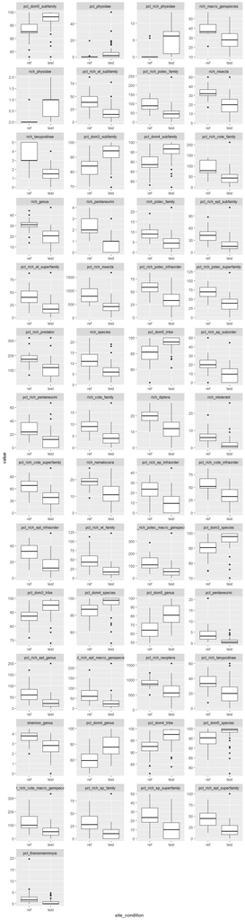

```r
sensitivity.df %>%
  filter(barbour == 3) %>%
  inner_join(metrics.long, by = "metric") %>%
  mutate(metric = factor(metric, levels = unique(metric))) %>%
  filter(site_condition != "ot") %>%
  ggplot(aes(site_condition, value)) +
  geom_boxplot() +
  facet_wrap(~metric, ncol = 4, scales = "free")
```

Plot the top 10 metrics with the best DE values.

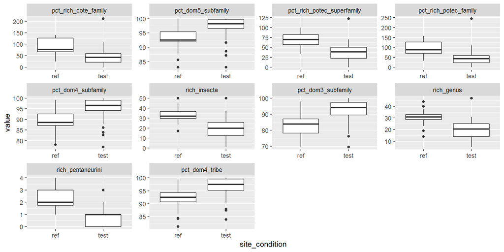

```r
sensitivity.df %>%
  arrange(desc(de)) %>%
  slice(1:10) %>%
  inner_join(metrics.long, by = "metric") %>%
  mutate(metric = factor(metric, levels = unique(metric))) %>%
  filter(site_condition != "ot") %>%
  ggplot(aes(site_condition, value)) +
  geom_boxplot() +
  facet_wrap(~metric, ncol = 4, scale = "free")
```

Plot the top 10 metrics with the best BDE values.

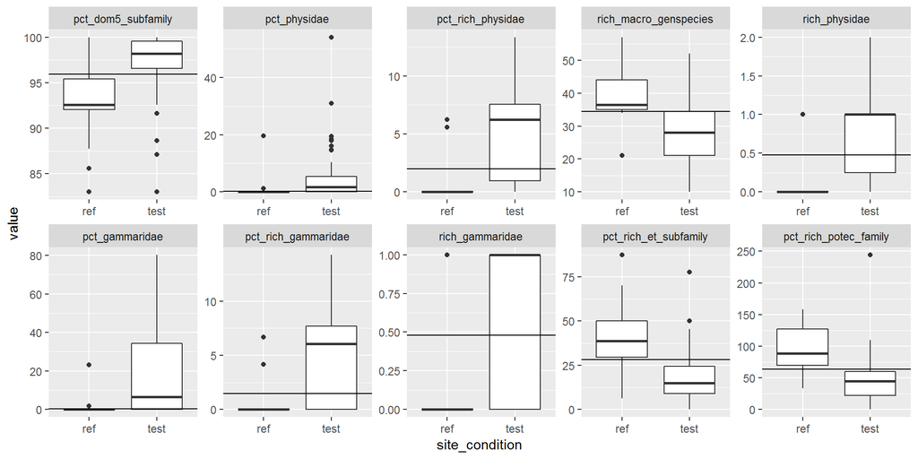

```r
sensitivity.df %>%
  arrange(desc(bde)) %>%
  slice(1:10) %>%
  inner_join(metrics.long, by = "metric") %>%
  mutate(metric = factor(metric, levels = unique(metric))) %>%
  filter(site_condition != "ot") %>%
  arrange(desc(bde)) %>%
  ggplot(aes(site_condition, value)) +
  geom_boxplot() +
  geom_hline(aes(yintercept = bde_thresh)) +
  facet_wrap(~metric, ncol = 5, scale = "free")
```

Plot an countidual metric.

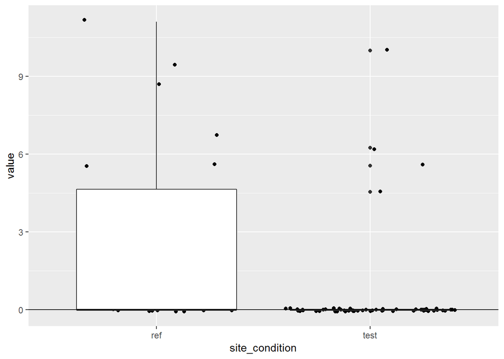

```r
sensitivity.df %>%
  filter(metric == "pct_rich_heptageniidae") %>%
  inner_join(metrics.long, by = "metric") %>%
  filter(site_condition != "ot") %>%
  arrange(desc(bde)) %>%
  ggplot(aes(site_condition, value)) +
  geom_jitter()+
  geom_boxplot() +
  geom_hline(aes(yintercept = bde_thresh))
```

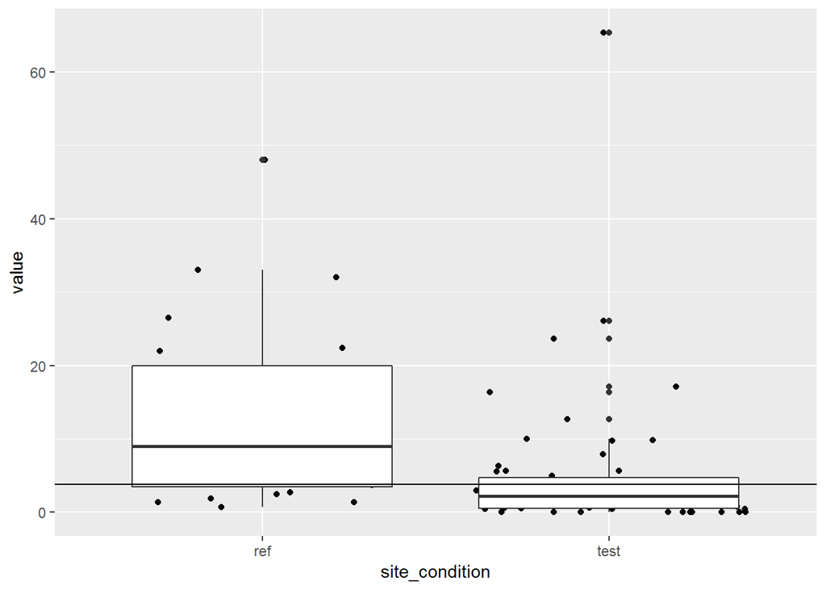

```r
sensitivity.df %>%
  filter(metric == "pct_ept") %>%
  inner_join(metrics.long, by = "metric") %>%
  filter(site_condition != "ot") %>%
  arrange(desc(bde)) %>%
  ggplot(aes(site_condition, value)) +
  geom_jitter()+
  geom_boxplot() +
  geom_hline(aes(yintercept = bde_thresh))
```